# Predicting Weight Lifting Exercises

## Synopsis

Using devices such as Jawbone Up, Nike FuelBand, and Fitbit it is now possible to collect a large amount of data about personal activity relatively inexpensively. These type of devices are part of the quantified self movement – a group of enthusiasts who take measurements about themselves regularly to improve their health, to find patterns in their behavior, or because they are tech geeks. One thing that people regularly do is quantify how much of a particular activity they do, but they rarely quantify how well they do it.

In this project, we will be using data from accelerometers on the belt, forearm, arm, and dumbbell of 6 participants. They were asked to perform barbell lifts correctly and incorrectly in 5 different ways and we will predict the manner in which they did the exercise.

## Data

The data for this project was taken from: http://web.archive.org/web/20161224072740/http:/groupware.les.inf.puc-rio.br/har (see the section on the Weight Lifting Exercise Dataset).

Six young health participants were asked to perform one set of 10 repetitions of the Unilateral Dumbbell Biceps Curl in five different fashions: exactly according to the specification (Class A), throwing the elbows to the front (Class B), lifting the dumbbell only halfway (Class C), lowering the dumbbell only halfway (Class D) and throwing the hips to the front (Class E). Class A corresponds to the specified execution of the exercise, while the other 4 classes correspond to common mistakes.

## Loading in the Data

Load in the required libraries.

```r
library(caret)
library(corrplot)
library(rpart)
library(rpart.plot)
library(randomForest)
library(gbm)
```

Load in the data from the site as follows:

```r
# Load file into directory
if (!file.exists("pml-training.csv") | (!file.exists("pml-testing.csv"))) {
    fileURL <- "https://d396qusza40orc.cloudfront.net/predmachlearn/pml-training.csv"
    fileURL2 <- "https://d396qusza40orc.cloudfront.net/predmachlearn/pml-testing.csv"

    download.file(fileURL,destfile = "./pml-training.csv", method = "curl")
    download.file(fileURL2,destfile = "./pml-testing.csv", method = "curl")
}

# Read in the training and test sets
train <- read.csv("pml-training.csv")
test <- read.csv("pml-testing.csv")
```

Our response variable `classe` consists of 5 different values as expected.

```r
unique(train$classe)
```

```
## [1] "A" "B" "C" "D" "E"
```

Observe the dimensions of the training and test sets.

```r
dim(train)
```

```
## [1] 19622   160
```

```r
dim(test)
```

```
## [1]  20 160
```

## Data Cleaning

Remove the first 5 columns as they are only for identification.

```r
train<- train[,-c(1:5)]
test<- test[,-c(1:5)]
```

Remove the variables that have multiple NA values.

```r
mul_NA <- sapply(train, function(x) mean(is.na(x))) > 0.90
train <- train[, mul_NA == FALSE]
test <- test[, mul_NA == FALSE]
```

Remove the variables with near zero variance. These variables have very little information because they mostly consist of a single value.

```r
near_zero <- nearZeroVar(train)
train <- train[, -near_zero]
test <- test[, -near_zero]
```

We check to see if there are any more missing values and find out the dimensions of the training and test sets after cleaning.

```r
colSums(is.na(train))
```

```
##           num_window            roll_belt           pitch_belt
##                    0                    0                    0
##             yaw_belt     total_accel_belt         gyros_belt_x
##                    0                    0                    0
##         gyros_belt_y         gyros_belt_z         accel_belt_x
##                    0                    0                    0
##         accel_belt_y         accel_belt_z        magnet_belt_x
##                    0                    0                    0
##        magnet_belt_y        magnet_belt_z             roll_arm
##                    0                    0                    0
##            pitch_arm              yaw_arm      total_accel_arm
##                    0                    0                    0
##          gyros_arm_x          gyros_arm_y          gyros_arm_z
##                    0                    0                    0
##          accel_arm_x          accel_arm_y          accel_arm_z
##                    0                    0                    0
##         magnet_arm_x         magnet_arm_y         magnet_arm_z
##                    0                    0                    0
##        roll_dumbbell       pitch_dumbbell         yaw_dumbbell
##                    0                    0                    0
## total_accel_dumbbell     gyros_dumbbell_x     gyros_dumbbell_y
##                    0                    0                    0
##     gyros_dumbbell_z     accel_dumbbell_x     accel_dumbbell_y
##                    0                    0                    0
##     accel_dumbbell_z    magnet_dumbbell_x    magnet_dumbbell_y
##                    0                    0                    0
##    magnet_dumbbell_z         roll_forearm        pitch_forearm
##                    0                    0                    0
##          yaw_forearm  total_accel_forearm      gyros_forearm_x
##                    0                    0                    0
##      gyros_forearm_y      gyros_forearm_z      accel_forearm_x
##                    0                    0                    0
##      accel_forearm_y      accel_forearm_z     magnet_forearm_x
##                    0                    0                    0
##     magnet_forearm_y     magnet_forearm_z               classe
##                    0                    0                    0
```

```r
dim(train)
```

```
## [1] 19622    54
```

```r
dim(test)
```

```
## [1] 20 54
```

## Correlation Plot

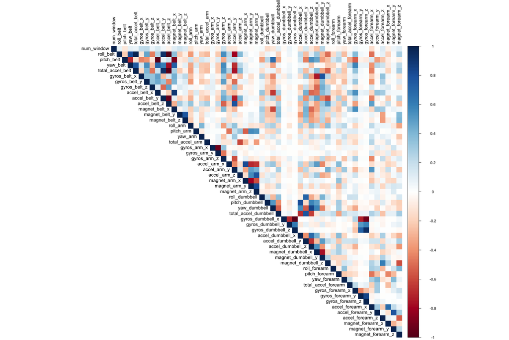

```r
corrplot(cor(train[,-54]), type="upper", method="color", tl.col = rgb(0, 0, 0))
```

From the above plot, we observe that there are only a few variables that are highly correlated. Principal Component Analysis does not appear to be necessary.

## Data Splitting

The test set will be put aside for now and to be used later for the prediction quiz. Split the training dataset into training and validation sets and check their dimensions.

```r
set.seed(101)
inTrain  <- createDataPartition(train$classe, p=0.7, list=FALSE)
train_set <- train[inTrain, ]
valid_set  <- train[-inTrain, ]

dim(train_set)
```

```
## [1] 13737    54
```

```r
dim(valid_set)
```

```
## [1] 5885   54
```

## Model Building

The following models will be used to fit the data:

1. Decision Tree
2. Random Forest
3. Gradient Boosting

### Decision Tree

Create a decision tree and plot it as follows:

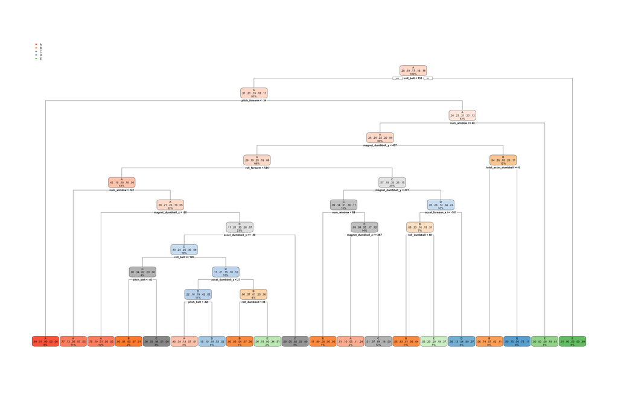

```r
set.seed(101)
rpart_model <- rpart(classe ~ ., data=train_set, method="class")
rpart.plot(rpart_model)
```

Use the model to predict the validation set and determine the confusion matrix and accuracy.

```r
rpart_pred <- predict(rpart_model, valid_set, type="class")
table(rpart_pred, valid_set$classe)
```

```
##
## rpart_pred    A    B    C    D    E
##          A 1494  250   47   78   50
##          B   51  635   33   32   81
##          C   10   54  766  137   64
##          D   98  112  108  544   47
##          E   21   88   72  173  840
```

```r
mean(rpart_pred == valid_set$classe)
```

```
## [1] 0.7271028
```

### Random Forest

Create a random forest as follows:

```r
set.seed(101)
rf_control <- trainControl(method="cv", number=3)
rf_model <- train(classe ~ ., data=train_set, trControl= rf_control, method="rf")
```

Use the model to predict the validation set and determine the confusion matrix and accuracy.

```r
rf_pred <- predict(rf_model, valid_set)
table(rf_pred, valid_set$classe)
```

```
##
## rf_pred    A    B    C    D    E
##       A 1673    5    0    0    0
##       B    0 1131    0    0    0
##       C    0    3 1026    2    0
##       D    0    0    0  961    0
##       E    1    0    0    1 1082
```

```r
mean(rf_pred == valid_set$classe)
```

```
## [1] 0.9979609
```

### Gradient Boosting

Create a gradient boosting algorithm as follows:

```r
set.seed(101)
gbm_control <- trainControl(method = "cv", number = 3)
gbm_model = train(classe ~., data=train_set, method="gbm", trControl= gbm_control, verbose = FALSE)
```

Use the model to predict the validation set and determine the confusion matrix and accuracy.

```r
gbm_pred <- predict(gbm_model, valid_set)
table(gbm_pred, valid_set$classe)
```

```
##
## gbm_pred    A    B    C    D    E
##        A 1669    8    0    0    0
##        B    5 1121   13    8    5
##        C    0   10 1009   19    3
##        D    0    0    4  935    9
##        E    0    0    0    2 1065
```

```r
mean(gbm_pred == valid_set$classe)
```

```
## [1] 0.9853866
```

Comparing the 3 models, the model with the highest accuracy is random forest, with an accuracy of 99.8%.

## Running Model on Test Set

```r
pred <- predict(rf_model, test)
pred
```

```
##  [1] B A B A A E D B A A B C B A E E A B B B
## Levels: A B C D E
```